# sex_effects_acute

2026-03-11

## Review Comment:

The cohort is 72% female, yet the manuscript fails to analyze whether molecular responses differ by sex. Given the well-established biological sexual dimorphism in exercise responses, this is a major oversight. Consequently, it is unclear whether the results are generalizable or primarily reflect the physiology of the female majority. The authors should perform and report a sex-stratified analysis or, at minimum, discuss this potential bias as a significant limitation.

## How to address this comment

The way we currently model the DA, we are essentially averaging any changes across male and female participants. We do have a covariate for sex, which is estimated across all groups + timepoints, but this does not really answer if we see a sexual dimorphism for the response for a specific group and timepoint, and if this dimorphism is being “averaged-out” by our modeling stratey.

Instead, we want to try to estimate the effect of exercise in a specific sex and specific exercise group independently, and see if the directions of change are similar between the sex-group-timepoint combinations.

### **Caveats**

1. The major reason we avoided this is because in most cases, the number of samples for a sex-group-timepoint can be very limited (especially for smaller male groups). Any conclusions have to be made with the understanding some of the potential differences (or lack of differences) may be due to sampling limitations

Therefore, I am proposing we describe these to reviewers + clarify that any results are descriptive in nature only and a point of possible comparison.

The sex-based differential analysis is described in `MotrpacHumanPreSuspensionAnalysis/data-raw/generate_differential_analysis.R`. Because there are many more parameters to estimate, I am no longer adjusting for initial clinical site, bc the model matrix will not be full rank.

### What does the data look like in the first place?

Let’s start by visualizing the distribution of Male vs Female participants per group and timepoint first.

So I’m going to start with the same initial filtering criteria we use in the landscape. Each cell must have at least 3 observations, e.g. every sex-group-timepoint must have 3 male participants + 3 female.

## Discusison for metab platform to include.

Because there are multiple metabolomics platforms, I choose to visualize just Hilic Positive, although the metab platforms generally are very similar in terms of n.

# Sex Distribution by Timepoint and Group

Visualize # of participants per sex-group-timepoint.

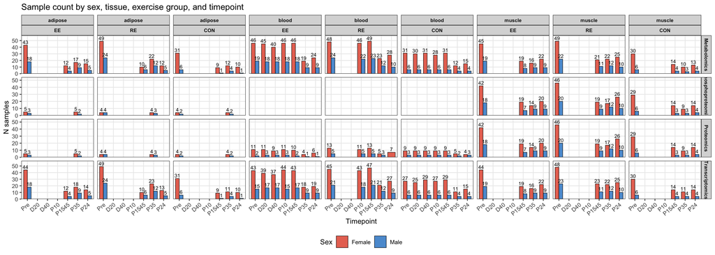

```r
ggplot(sex_dist_plot, aes(x = tp, y = n, fill = Sex)) +
  geom_col(position = "dodge", color = "black", linewidth = 0.25, width = 0.75) +
  geom_text(
    aes(label = n),
    position = position_dodge(width = 0.75),
    vjust = -0.35,
    size = 2.5
  ) +
  facet_grid(Ome ~ tissue + Group, scales = "free_y") +
  scale_fill_manual(values = sex_colors) +
  scale_y_continuous(expand = expansion(mult = c(0, 0.18))) +
  labs(
    x = "Timepoint", y = "N samples",
    title = "Sample count by sex, tissue, exercise group, and timepoint"
  ) +
  theme_bw(base_size = 10) +
  theme(
    strip.text       = element_text(size = 7, face = "bold"),
    axis.text.x      = element_text(size = 8, angle = 40, hjust = 1),
    panel.grid.minor = element_blank(),
    legend.position  = "bottom"
  )
```

# Targeted Data Overview: Sample-Level PCA by Sex

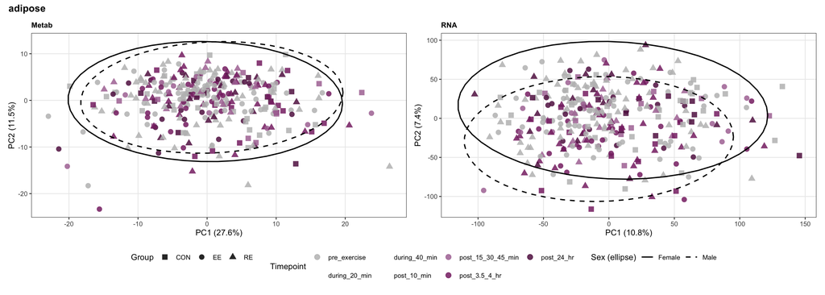

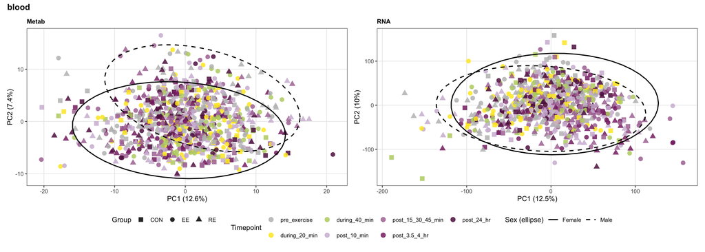

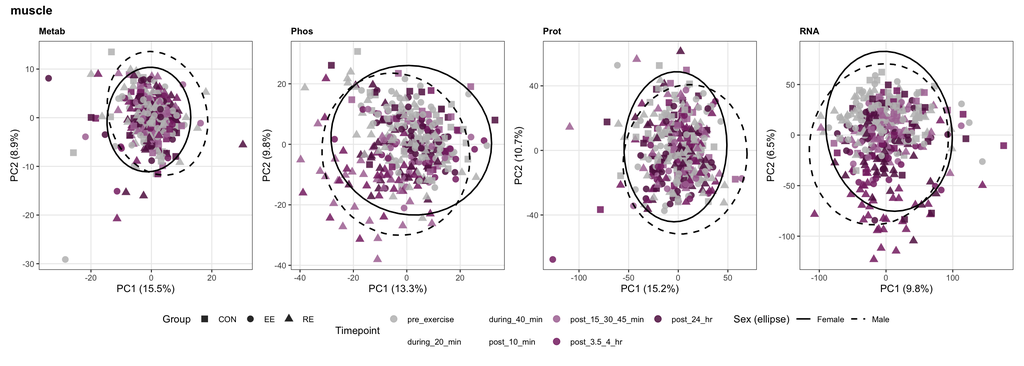

```r
tp_levels = c("pre_exercise", "during_20_min", "during_40_min",
              "post_10_min", "post_15_30_45_min", "post_3.5_4_hr", "post_24_hr")
tp_colors_pca = MotrpacHumanPreSuspensionAnalysis::HUMAN_ACUTE_TIMEPOINT_COLORS
tp_colors_pca = tp_colors_pca[tp_levels]

pca_plots = list()

for (i in seq_len(nrow(qualifying_omes_tissues))) {
  tiss = qualifying_omes_tissues$tissue[i]
  ome  = qualifying_omes_tissues$assay[i]

  ome_data = all_dataset[[tiss]][[ome]]
  if (is.null(ome_data)) next

  p = make_pca_panel(tiss, ome, ome_data, tp_levels, tp_colors_pca)
  if (!is.null(p)) {
    if (is.null(pca_plots[[tiss]])) pca_plots[[tiss]] = list()
    pca_plots[[tiss]][[ome]] = p
  }
}

for (tiss in names(pca_plots)) {
  panels = pca_plots[[tiss]]
  print(
    patchwork::wrap_plots(panels, ncol = min(5, length(panels))) +
      patchwork::plot_layout(guides = "collect") +
      patchwork::plot_annotation(
        title = tiss,
        theme = theme(plot.title = element_text(size = 12, face = "bold"))
      ) &
      theme(legend.position = "bottom")
  )
}
```

# Male vs. Female logFC Scatter

Per-facet correlation using significant features only, computed per Group × Timepoint. Note: correlations are of logFC point estimates (exercise vs. pre-exercise) restricted to EE and RE; control-group comparisons are excluded given the low per-sex n in controls makes those point estimates unreliable.

```r
scatter_wide = sex_single_da_annotated %>%
  dplyr::select(tissue, assay, platform, feature_id, randomGroupCode, Timepoint,
                sex_comparison, logFC, CI.L, CI.R, adj_p_value, pre_cawg_adj_p) %>%
  tidyr::pivot_wider(
    names_from  = sex_comparison,
    values_from = c(logFC, CI.L, CI.R, adj_p_value)
  ) %>%
  dplyr::filter(!is.na(logFC_Male), !is.na(logFC_Female)) %>%
  dplyr::mutate(
    Ome = dplyr::case_when(
      grepl("metab", assay)              ~ "Metabolomics",
      assay == "prot-ph"                 ~ "Phosphoproteomics",
      assay %in% c("prot-pr", "prot-ol") ~ "Proteomics",
      grepl("rna",  assay)               ~ "Transcriptomics",
      TRUE ~ assay
    ),
    Ome = factor(Ome, levels = c("Transcriptomics", "Proteomics",
                                 "Phosphoproteomics", "Metabolomics")),
    Group = dplyr::recode(randomGroupCode,
                          "ADUEndur" = "EE", "ADUResist" = "RE", "ADUControl" = "CON"),
    Group = factor(Group, levels = c("EE", "RE", "CON"))
  )

# Exported for downstream deep dives (e.g. adipose_concordance_deep_dive.Rmd).
saveRDS(scatter_wide,
        here::here("revisions/landscape/sex_sensitivity_analysis/outputs/scatter_wide.rds"))

scatter_sig_features = scatter_wide %>%
  dplyr::filter(!is.na(pre_cawg_adj_p) & pre_cawg_adj_p < 0.05, Group != "CON")

scatter_cor = scatter_sig_features %>%
  dplyr::group_by(Ome, tissue, Group, Timepoint) %>%
  dplyr::summarise(
    n_sig = dplyr::n(),
    Pearsons_R = round(cor(logFC_Female, logFC_Male, method = "pearson", use = "complete.obs"), 3),
    slope = {
      complete = !is.na(logFC_Female) & !is.na(logFC_Male)
      if (sum(complete) >= 2) coef(lm(logFC_Male[complete] ~ logFC_Female[complete]))[2] else NA_real_
    },
    intercept = {
      complete = !is.na(logFC_Female) & !is.na(logFC_Male)
      if (sum(complete) >= 2) coef(lm(logFC_Male[complete] ~ logFC_Female[complete]))[1] else NA_real_
    },
    .groups = "drop"
  ) %>%
  dplyr::mutate(dplyr::across(c(Ome, tissue, Group, Timepoint), as.character))

# Overall correlation pooling all significant features across every tissue,
# ome, group, and timepoint included in the DA.
overall_cor = scatter_sig_features %>%
  dplyr::summarise(
    Ome = "All", tissue = "All", Group = "All", Timepoint = "All",
    n_sig = dplyr::n(),
    Pearsons_R = round(cor(logFC_Female, logFC_Male, method = "pearson", use = "complete.obs"), 3),
    slope = {
      complete = !is.na(logFC_Female) & !is.na(logFC_Male)
      if (sum(complete) >= 2) coef(lm(logFC_Male[complete] ~ logFC_Female[complete]))[2] else NA_real_
    },
    intercept = {
      complete = !is.na(logFC_Female) & !is.na(logFC_Male)
      if (sum(complete) >= 2) coef(lm(logFC_Male[complete] ~ logFC_Female[complete]))[1] else NA_real_
    }
  )

scatter_cor = dplyr::bind_rows(scatter_cor, overall_cor)

knitr::kable(
  dplyr::bind_rows(
    scatter_cor %>%
      dplyr::filter(tissue != "All", n_sig > 100) %>%
      dplyr::arrange(tissue, Ome, Group, Timepoint),
    scatter_cor %>% dplyr::filter(tissue == "All")
  ),
  digits = 3,
  col.names = c("Ome", "Tissue", "Group", "Timepoint", "N sig", "Pearson's R", "Slope", "Intercept"),
  caption = "Male vs Female logFC correlations (significant preCAWG features, n > 100; final row is the overall correlation across all tissues and omes)"
)
```

Male vs Female logFC correlations (significant preCAWG features, n > 100; final row is the overall correlation across all tissues and omes)

| Ome | Tissue | Group | Timepoint | N sig | Pearson’s R | Slope | Intercept |
| --- | --- | --- | --- | --- | --- | --- | --- |
| Metabolomics | blood | EE | during_20_min | 159 | 0.954 | 1.025 | 0.012 |
| Metabolomics | blood | EE | during_40_min | 163 | 0.941 | 1.074 | 0.031 |
| Metabolomics | blood | EE | post_10_min | 161 | 0.923 | 1.040 | 0.077 |
| Metabolomics | blood | RE | post_10_min | 236 | 0.961 | 1.295 | -0.019 |
| Metabolomics | blood | RE | post_15_30_45_min | 219 | 0.951 | 1.331 | 0.003 |
| Metabolomics | blood | RE | post_3.5_4_hr | 138 | 0.908 | 1.014 | 0.064 |
| Transcriptomics | blood | EE | during_20_min | 2180 | 0.921 | 1.237 | 0.019 |
| Transcriptomics | blood | EE | during_40_min | 1867 | 0.916 | 1.232 | 0.048 |
| Transcriptomics | blood | EE | post_10_min | 439 | 0.902 | 1.211 | 0.068 |
| Transcriptomics | blood | EE | post_15_30_45_min | 840 | 0.875 | 0.925 | 0.012 |
| Transcriptomics | blood | EE | post_3.5_4_hr | 2415 | 0.895 | 0.994 | -0.004 |
| Transcriptomics | blood | RE | post_10_min | 1017 | 0.894 | 1.444 | 0.010 |
| Transcriptomics | blood | RE | post_15_30_45_min | 2565 | 0.888 | 1.344 | -0.002 |
| Transcriptomics | blood | RE | post_3.5_4_hr | 3773 | 0.922 | 1.593 | 0.033 |
| Transcriptomics | muscle | EE | post_15_30_45_min | 980 | 0.973 | 1.007 | 0.015 |
| Transcriptomics | muscle | EE | post_24_hr | 1284 | 0.897 | 1.082 | 0.007 |
| Transcriptomics | muscle | EE | post_3.5_4_hr | 2314 | 0.956 | 1.038 | 0.018 |
| Transcriptomics | muscle | RE | post_15_30_45_min | 883 | 0.965 | 1.122 | 0.005 |
| Transcriptomics | muscle | RE | post_24_hr | 3458 | 0.940 | 0.965 | 0.004 |
| Transcriptomics | muscle | RE | post_3.5_4_hr | 5611 | 0.956 | 1.105 | 0.001 |
| All | All | All | All | 31162 | 0.926 | 1.126 | 0.017 |

```r
write.csv(scatter_cor, here::here("revisions/landscape/sex_sensitivity_analysis/outputs/m_vs_f_response_correlation.csv"), row.names = FALSE)
```

```
## `height` was translated to `width`.
```

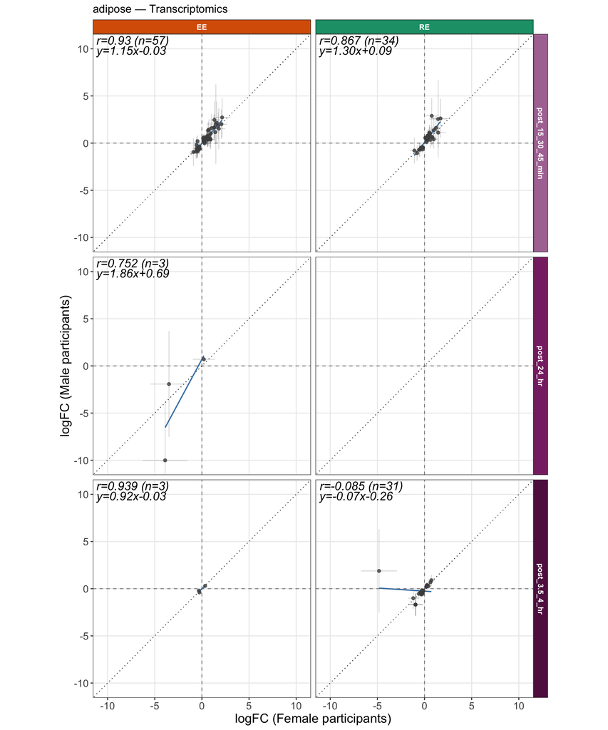

```
## `height` was translated to `width`.
```

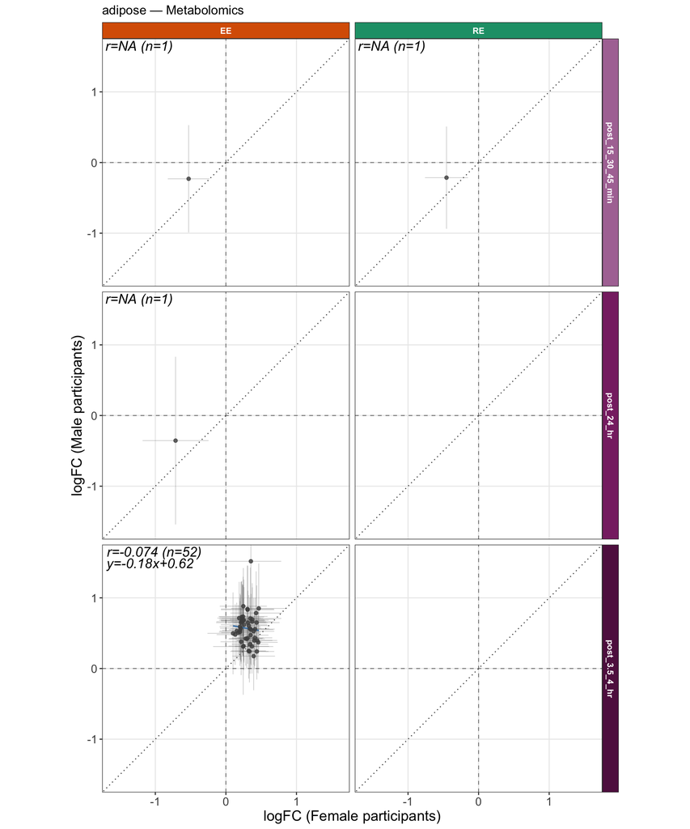

```
## `height` was translated to `width`.
```

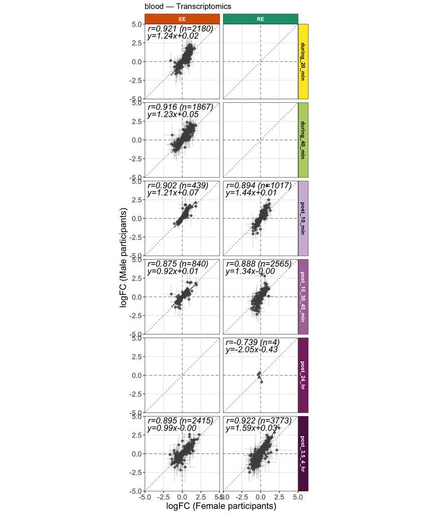

```
## `height` was translated to `width`.
```

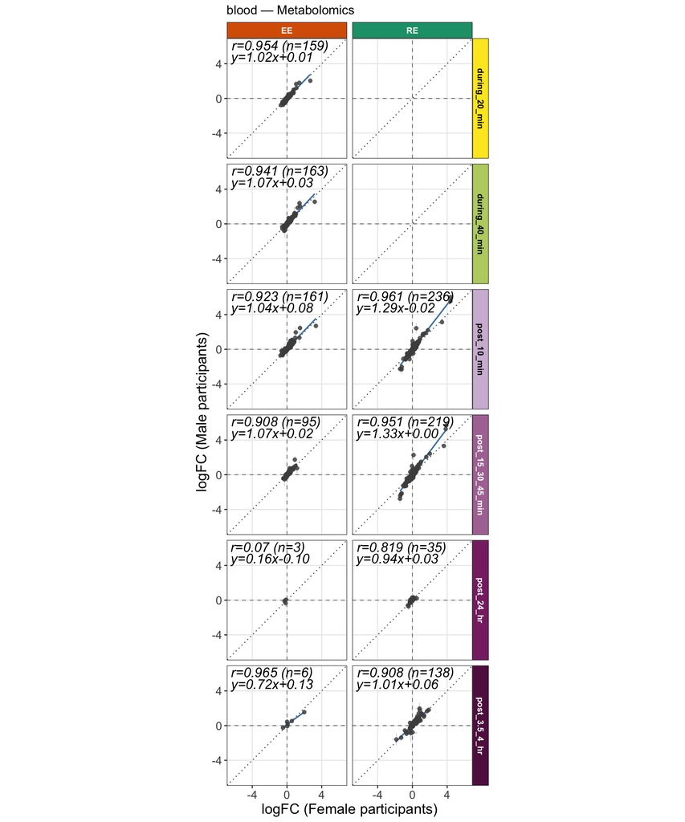

```
## `height` was translated to `width`.
```

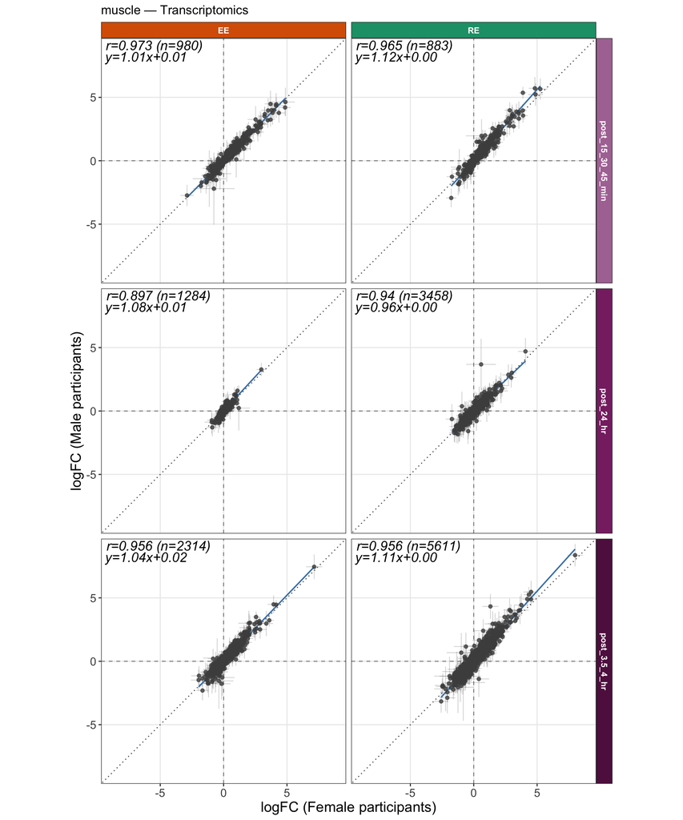

```
## `height` was translated to `width`.
```

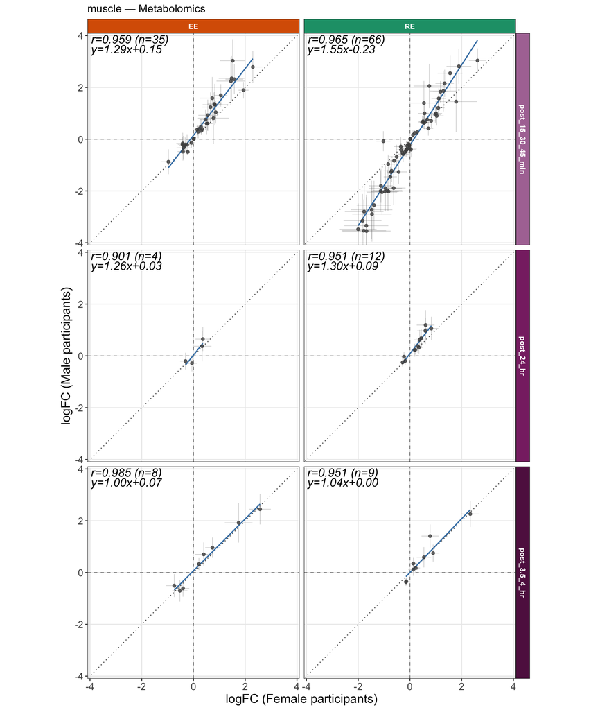

```r
# One plot per tissue × ome, faceted by Timepoint × Group (EE/RE only).
scatter_sig = scatter_wide %>%
  dplyr::filter(!is.na(pre_cawg_adj_p) & pre_cawg_adj_p < 0.05, Group != "CON")

tissue_ome_combos = scatter_sig %>%
  dplyr::distinct(tissue, Ome) %>%
  dplyr::arrange(tissue, Ome)

for (i in seq_len(nrow(tissue_ome_combos))) {
  tiss     = tissue_ome_combos$tissue[i]
  ome_type = tissue_ome_combos$Ome[i]
  p = .make_sex_scatter(tiss, ome_type, scatter_sig, scatter_cor)
  if (!is.null(p)) print(p)
}
```

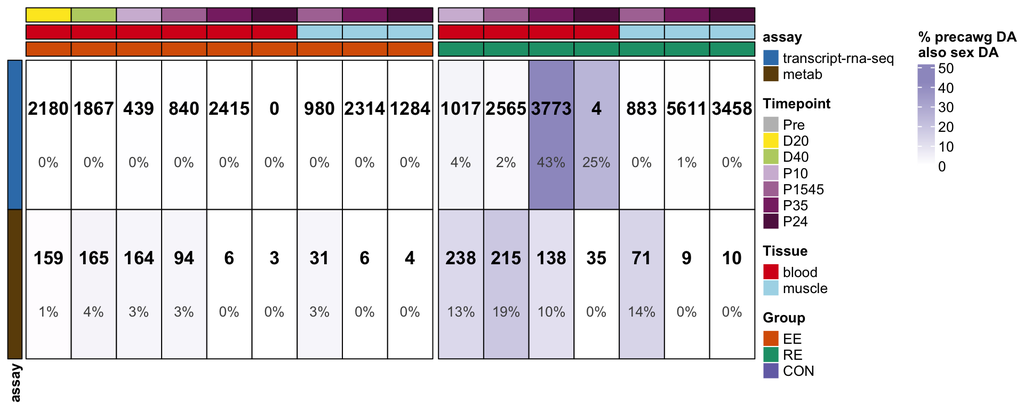

```r
plot_precawg_mvsf_matrix(precawg_and_m_vs_f_diff %>% filter(tissue != "adipose"))
```

```
## `height` was translated to `width`.
## `height` was translated to `width`.
```

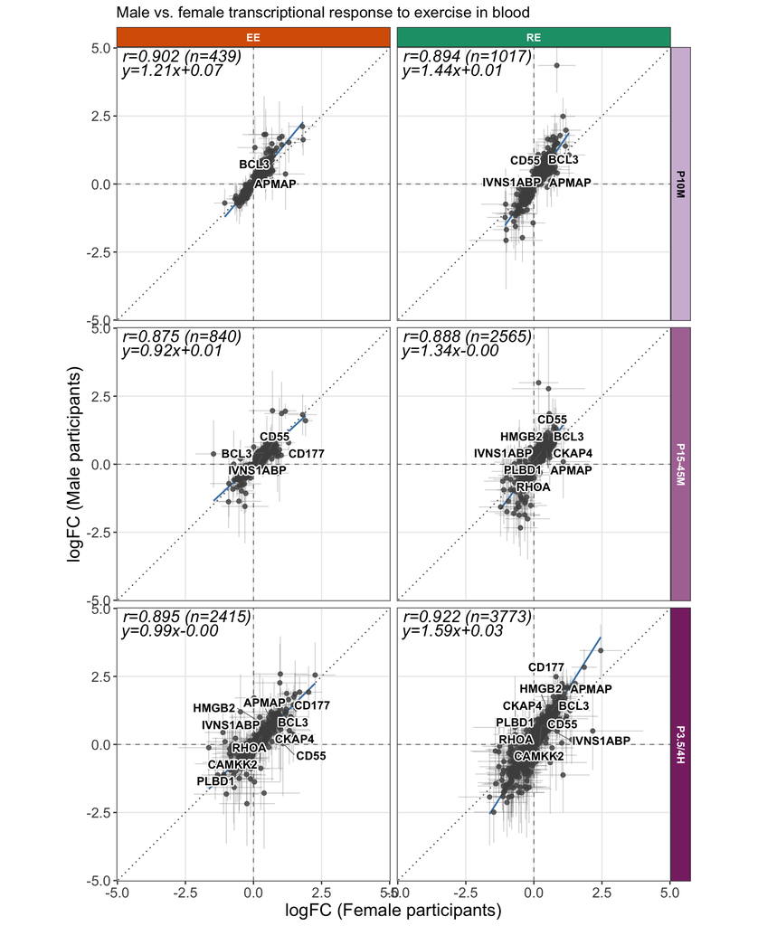

```r
post_timepoints = c("post_10_min", "post_15_30_45_min", "post_3.5_4_hr")

# Top 10 most significant (smallest sex-difference p-value) features from RE at post 3.5/4 hr;
# label this same set in every panel.
highlight_ids = precawg_and_m_vs_f_diff %>%
  dplyr::filter(tissue == "blood",
                assay == "transcript-rna-seq",
                randomGroupCode == "ADUResist",
                Timepoint == "post_3.5_4_hr") %>%
  dplyr::slice_min(adj_p_value_sex_diff, n = 10, with_ties = FALSE) %>%
  dplyr::pull(feature_id)

tp_labels = c(
  "post_10_min"       = "P10M",
  "post_15_30_45_min" = "P15-45M",
  "post_3.5_4_hr"     = "P3.5/4H"
)

prettify_facets = function(df) {
  df %>%
    dplyr::mutate(
      Timepoint = factor(dplyr::recode(as.character(Timepoint), !!!tp_labels),
                         levels = unname(tp_labels)),
      Group = factor(Group, levels = c("EE", "RE"))
    )
}

blood_post = scatter_wide %>%
  dplyr::filter(tissue == "blood",
                Group %in% c("EE", "RE"),
                Timepoint %in% post_timepoints,
                pre_cawg_adj_p < 0.05) %>%
  prettify_facets()

blood_post_cor = scatter_cor %>%
  dplyr::filter(tissue == "blood", Group %in% c("EE", "RE"), Timepoint %in% post_timepoints) %>%
  prettify_facets()

p = .make_sex_scatter("blood", "Transcriptomics", blood_post, blood_post_cor,
                      highlight_ids = highlight_ids)
if (!is.null(p)) {
  p = p + labs(
    title = "Male vs. female transcriptional response to exercise in blood"
  )
  print(p)
  ggsave(here::here("revisions/landscape/sex_sensitivity_analysis/outputs/scatter_blood_EE_RE_post.png"),
         plot = p, width = 9, height = 11, dpi = 900, units = "in")
}
```

**Figure legend.** *Sex-stratified transcriptional response to acute exercise in blood.* Exercise-induced log fold-changes (logFC, post-exercise relative to pre-exercise) were estimated separately in male and female participants and are plotted against one another for blood transcripts: female logFC on the x-axis and male logFC on the y-axis. Panels are arranged by post-exercise timepoint (rows: P10M, 10 min post; P15-45M, 15/30/45 min post; P3.5/4H, 3.5/4 h post) and exercise mode (columns: EE, endurance exercise; RE, resistance exercise). Each point is a transcript that was significant in the primary, sex-combined PreCAWG differential analysis (BH-adjusted *p* < 0.05); horizontal and vertical bars show the 95% confidence intervals of the female and male logFC estimates, respectively. The dotted diagonal is the line of identity (equal response in both sexes) and the blue line is the ordinary least-squares fit; the Pearson correlation (*r*), the number of features (*n*), and the regression equation are annotated in each panel. Labeled transcripts are the 10 features with the smallest sex-difference adjusted *p*-values in resistance exercise at the 3.5/4 h timepoint, shown in every panel for reference. Dashed grey lines mark zero logFC.

```r
annotated_differences = precawg_and_m_vs_f_diff %>%
  left_join(HUMAN_FEATURE_TO_GENE %>% filter(assay == "transcript-rna-seq"), by = c("feature_id", "assay"))

sig_differences = annotated_differences %>%
  dplyr::filter(Timepoint == "post_3.5_4_hr",
                randomGroupCode == "ADUResist",
                assay == "transcript-rna-seq",
                tissue == "blood",
                adj_p_value_precawg < 0.05 & adj_p_value_sex_diff < 0.05)
write.csv(sig_differences, "outputs/sig_differences_blood_RE_P35_rna.csv", row.names = FALSE)

all_blood_transcripts = unique(annotated_differences %>% dplyr::filter(assay == "transcript-rna-seq", tissue == "blood") %>% pull(gene_symbol)) %>% as.character()

ora_results = run_ORA(
  input = sig_differences$gene_symbol %>% as.character(),
  background = all_blood_transcripts
)
write.csv(ora_results, "outputs/ora_blood_RE_P35_rna.csv", row.names = FALSE)
ora_results %>% dplyr::filter(collection != "CELLMARKER") %>% dplyr::select(set_short, adj_p_value) %>% head(20)
```

```
##                                                     set_short  adj_p_value
## 1                               REACTOME_INNATE_IMMUNE_SYSTEM 7.302169e-79
## 2                           REACTOME_NEUTROPHIL_DEGRANULATION 6.236987e-75
## 3                                      GOCC_SECRETORY_GRANULE 3.487518e-58
## 4                                      GOCC_SECRETORY_VESICLE 5.359153e-56
## 5                             GOCC_SECRETORY_GRANULE_MEMBRANE 4.475785e-38
## 6                                       GOBP_DEFENSE_RESPONSE 4.317461e-34
## 7                                       GOCC_VESICLE_MEMBRANE 7.242771e-34
## 8                    GOBP_REGULATION_OF_IMMUNE_SYSTEM_PROCESS 1.008707e-32
## 9  GOBP_BIOLOGICAL_PROCESS_INVOLVED_IN_INTERSPECIES...(00649) 1.995749e-32
## 10                         GOBP_REGULATION_OF_IMMUNE_RESPONSE 4.142205e-30
## 11          GOBP_POSITIVE_REGULATION_OF_IMMUNE_SYSTEM_PROCESS 6.671718e-30
## 12                                GOCC_FICOLIN_1_RICH_GRANULE 6.812345e-30
## 13                                       GOBP_CELL_ACTIVATION 5.854431e-28
## 14               REACTOME_CYTOKINE_SIGNALING_IN_IMMUNE_SYSTEM 9.745478e-27
## 15                                      GOCC_TERTIARY_GRANULE 3.257260e-26
## 16                                      GOCC_SPECIFIC_GRANULE 1.682109e-24
## 17        GOBP_POSITIVE_REGULATION_OF_MULTICELLULAR...(04823) 5.038567e-24
## 18                    GOBP_DEFENSE_RESPONSE_TO_OTHER_ORGANISM 1.078296e-23
## 19                            GOBP_VESICLE_MEDIATED_TRANSPORT 1.787005e-23
## 20                                               GOCC_VACUOLE 1.848757e-23
```

# Transcripts included in PreCAWG Analysis

Essentially trying to answer - are we ignoring sexual dimorphism and actually only showing off results that correspond to the female phenotype

**Figure legend.** *Male and female responses for manuscript-highlighted transcripts (e.g., PPARGC1A, CCN1).* For each highlighted transcript, the mean normalized abundance (± 95% confidence interval) is shown at each timepoint for female (red), male (blue), and all (overall, black) participants, faceted by tissue–assay (rows) and exercise group (columns: CON, control; EE, endurance; RE, resistance). Timepoints: Pre, pre-exercise; D20M/D40M, 20/40 min during exercise; P10M, 10 min post; P15-45M, 15/30/45 min post; P3.5/4H, 3.5/4 h post; P24H, 24 h post. Concordant male and female trajectories indicate that the reported response for these features is not driven by the female-majority composition of the cohort. Per-sex sample sizes are reduced relative to the full-cohort analysis, so confidence intervals are wider and these panels should be interpreted as descriptive.

```r
manuscript_transcripts = c("NR4A1", "PPARGC1A", "MYC", "CCN1")
relevant_feature_ids = HUMAN_FEATURE_TO_GENE %>%
  dplyr::filter(assay == "transcript-rna-seq",
                gene_symbol %in% manuscript_transcripts) %>%
  dplyr::pull(feature_id) %>% as.character()

for (feat in relevant_feature_ids) {
  tryCatch({
    cat("\n\n###", feat, "\n\n")
    print(sex_differences_single_feature(feat))
    print(sex_differences_logfc_feature(feat))
  }, error = function(e) {
    message("Skipping ", feat, ": ", conditionMessage(e))
  })
}
```

[output not shown]

### ENSG00000109819.9

```
## The available tissues are placed into overarching categories. For example, an assay using PBMCs would be categorized as blood.
```

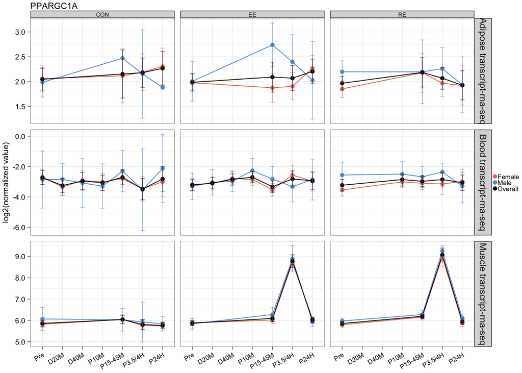

```
## Skipping ENSG00000109819.9: object 'precawg_and_sex_diff' not found
```

### ENSG00000123358.20

```
## The available tissues are placed into overarching categories. For example, an assay using PBMCs would be categorized as blood.
```

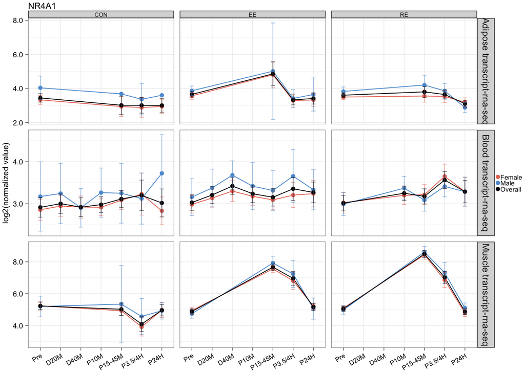

```
## Skipping ENSG00000123358.20: object 'precawg_and_sex_diff' not found
```

### ENSG00000136997.21

```
## The available tissues are placed into overarching categories. For example, an assay using PBMCs would be categorized as blood.
```

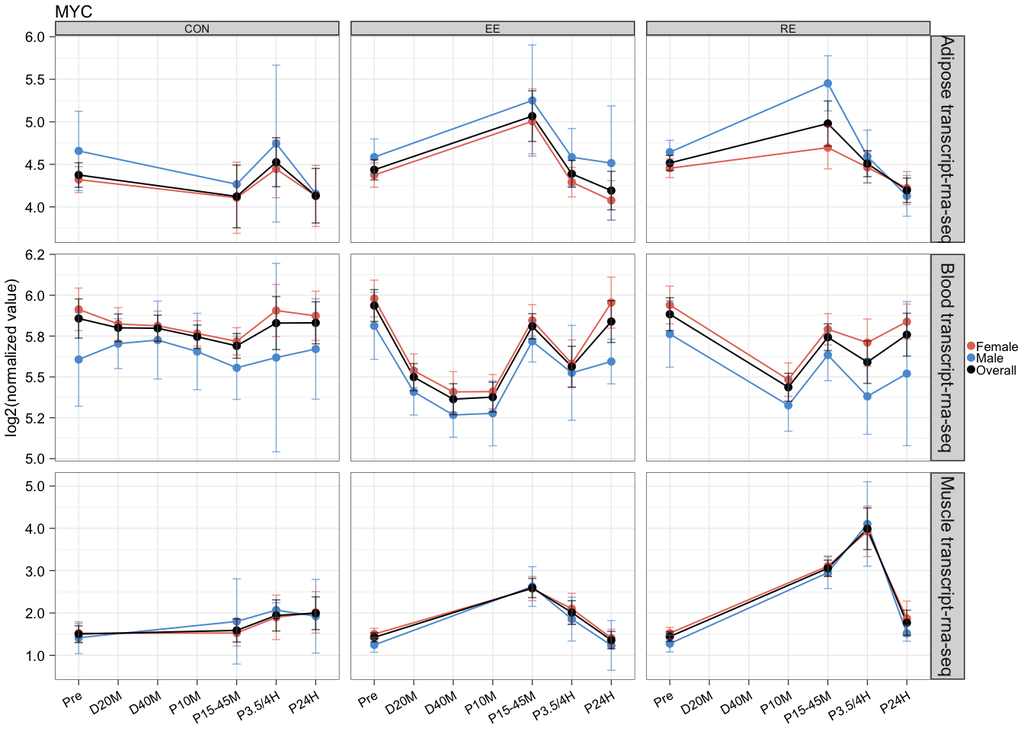

```
## Skipping ENSG00000136997.21: object 'precawg_and_sex_diff' not found
```

### ENSG00000142871.18

```
## The available tissues are placed into overarching categories. For example, an assay using PBMCs would be categorized as blood.
```

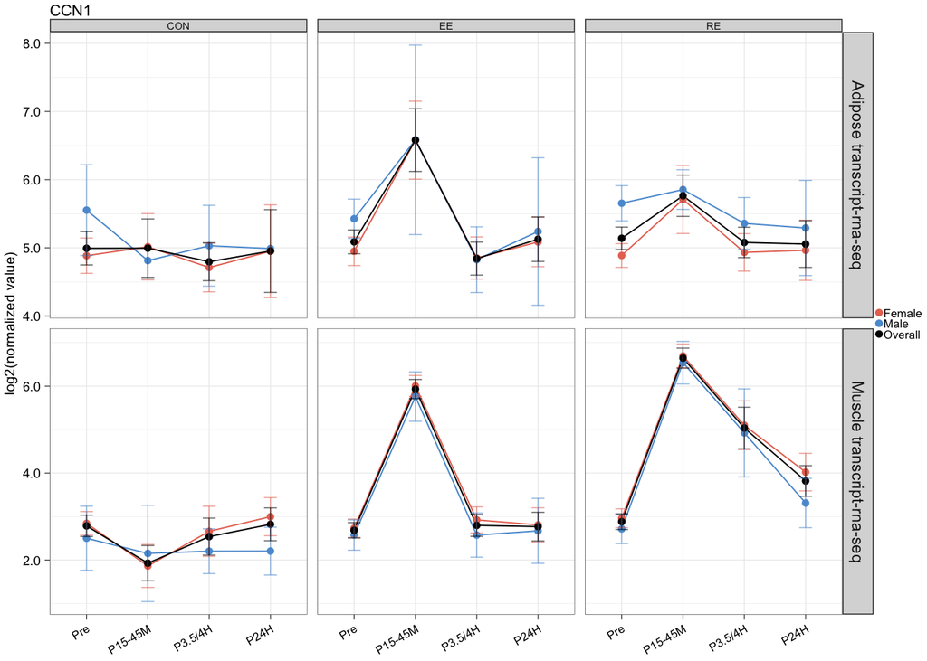

```
## Skipping ENSG00000142871.18: object 'precawg_and_sex_diff' not found
```

For PGC1a specifically we highlight just the muscle, its not really mentioned as much in the context of other tissues in the landscape.

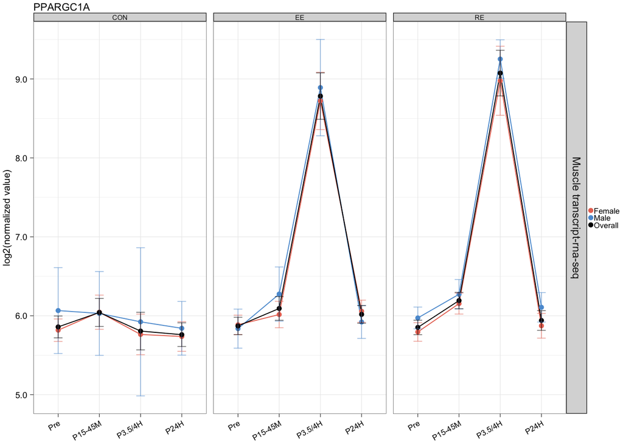

```r
print(sex_differences_single_feature("PPARGC1A", selected_tissues = "muscle", output_file = "outputs/PPARGC1A.png"))
```

# Metabs included in PreCAWG analysis

1. Carnitines, Glutamic acid, Citrate, Leucine + isoleucine, lactate

```r
manuscript_metabs = c("Lactic acid", "Leucine", "Isoleucine", "Glutamic acid")

for (feat in manuscript_metabs) {
  tryCatch({
    cat("\n\n###", feat, "\n\n")
    print(sex_differences_single_feature(feat))
    print(sex_differences_logfc_feature(feat))
  }, error = function(e) {
    message("Skipping ", feat, ": ", conditionMessage(e))
  })
}
```

[output not shown]

### Lactic acid

```
## The available tissues are placed into overarching categories. For example, an assay using PBMCs would be categorized as blood.
```

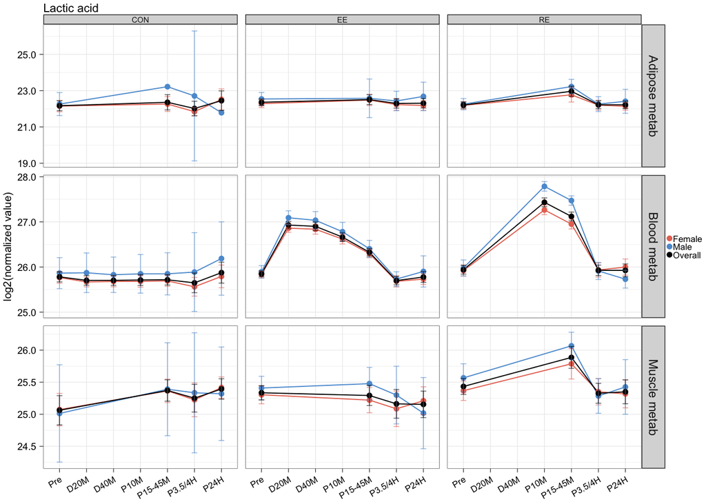

```
## Skipping Lactic acid: object 'precawg_and_sex_diff' not found
```

### Leucine

```
## The available tissues are placed into overarching categories. For example, an assay using PBMCs would be categorized as blood.
```

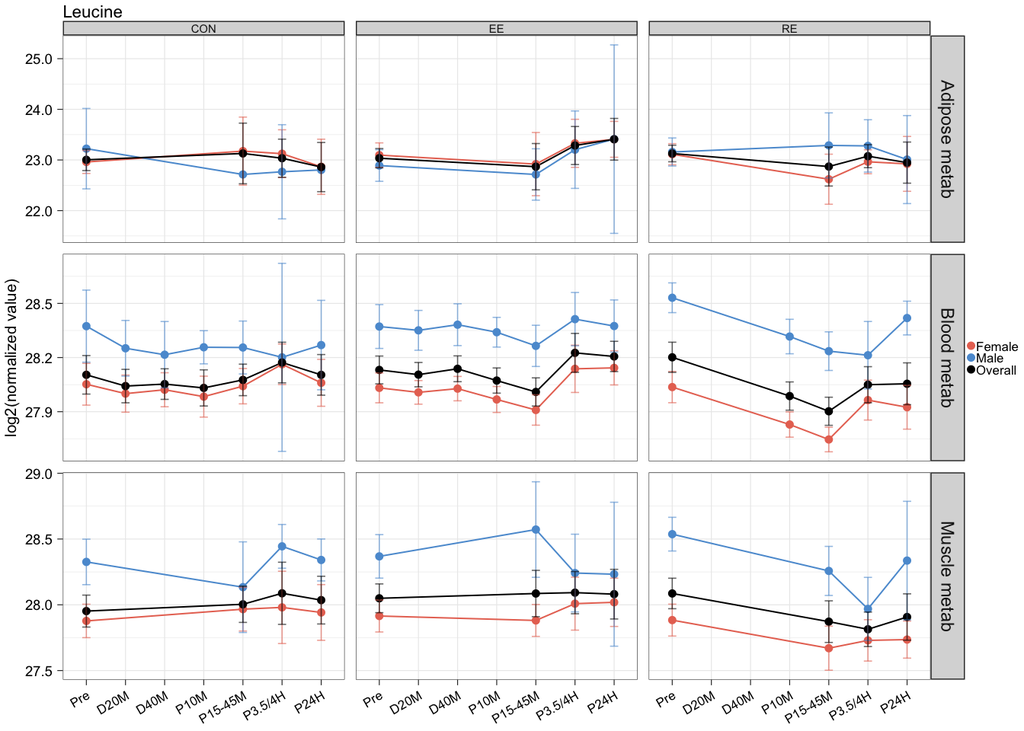

```
## Skipping Leucine: object 'precawg_and_sex_diff' not found
```

### Isoleucine

```
## The available tissues are placed into overarching categories. For example, an assay using PBMCs would be categorized as blood.
```

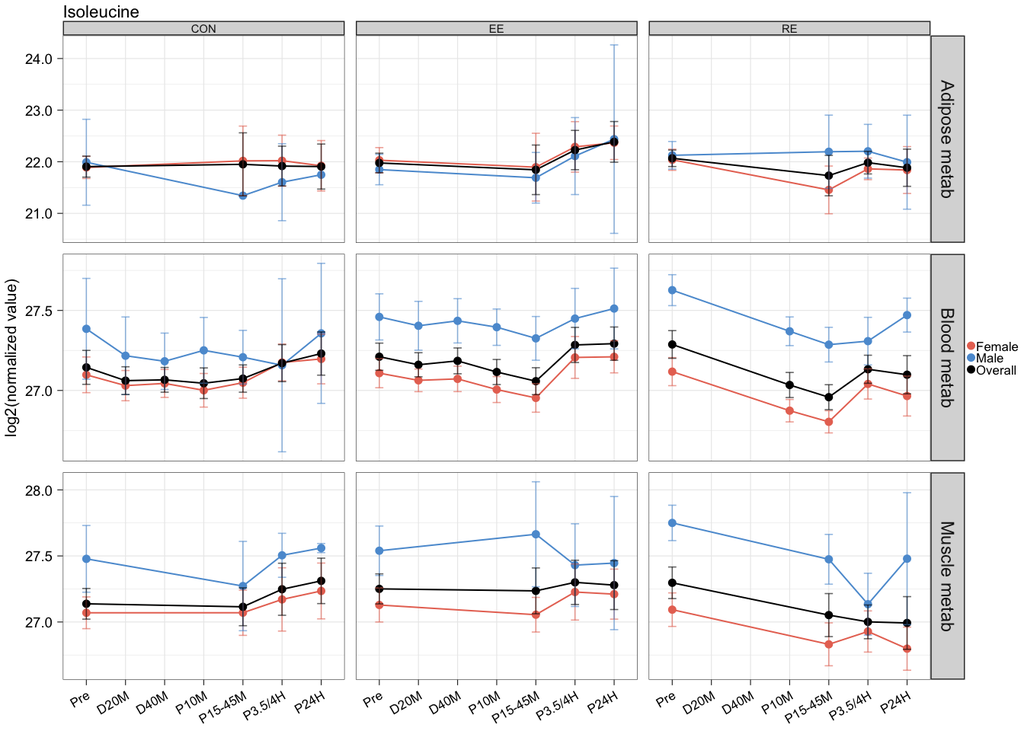

```
## Skipping Isoleucine: object 'precawg_and_sex_diff' not found
```

### Glutamic acid

```
## The available tissues are placed into overarching categories. For example, an assay using PBMCs would be categorized as blood.
```

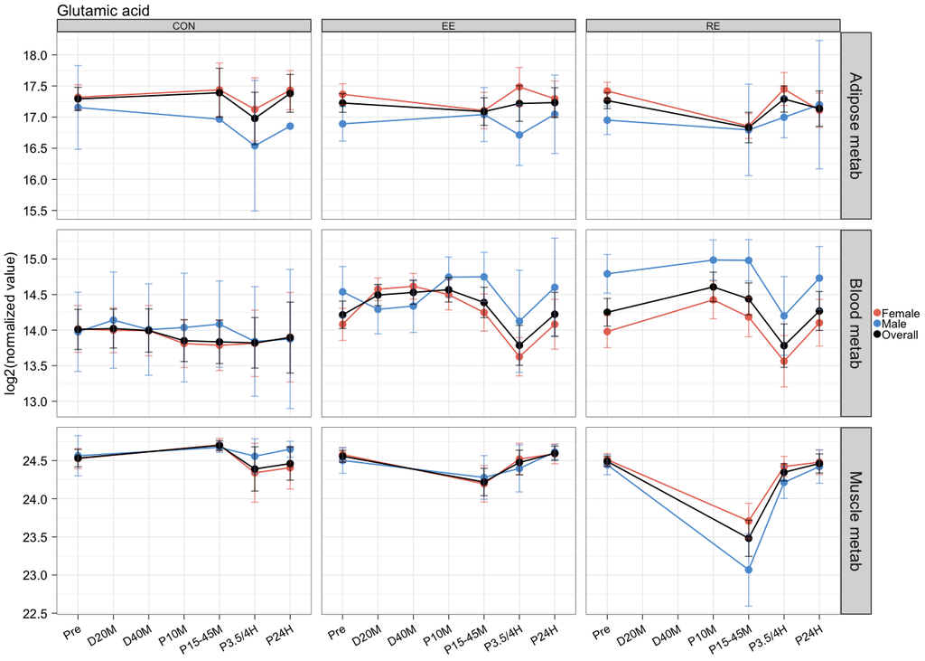

```
## Skipping Glutamic acid: object 'precawg_and_sex_diff' not found
```

# X/Y Linked Features

Identify features mapped to chromosomes X or Y in the sex DA.

```r
# Get chromosome annotations for all RNA-seq features in the sex DA
rna_features = read_sex_diff %>%
  dplyr::filter(grepl("rna", assay)) %>%
  dplyr::distinct(feature_id)

# Join gene symbols via HUMAN_FEATURE_TO_GENE
rna_gene_map = HUMAN_FEATURE_TO_GENE %>%
  dplyr::filter(assay == "transcript-rna-seq") %>%
  dplyr::select(feature_id, gene_symbol) %>%
  dplyr::distinct()

rna_features = rna_features %>%
  dplyr::left_join(rna_gene_map, by = "feature_id")

ensembl = tryCatch(
  biomaRt::useEnsembl("ensembl", dataset = "hsapiens_gene_ensembl"),
  error = function(e) {
    message("biomaRt unavailable, skipping chromosome annotation: ", e$message)
    NULL
  }
)

chrom_annotation = NULL
if (!is.null(ensembl)) {
  chrom_annotation = biomaRt::getBM(
    attributes = c("hgnc_symbol", "chromosome_name"),
    filters    = "hgnc_symbol",
    values     = rna_features$gene_symbol[!is.na(rna_features$gene_symbol)],
    mart       = ensembl
  ) %>%
    dplyr::filter(chromosome_name %in% c(as.character(1:22), "X", "Y")) %>%
    dplyr::distinct(hgnc_symbol, chromosome_name)
}
```

```r
sex_diff_rna_chrom = precawg_and_m_vs_f_diff %>%
  dplyr::filter(grepl("rna", assay)) %>%
  dplyr::left_join(rna_gene_map, by = "feature_id") %>%
  dplyr::left_join(chrom_annotation,
                   by = c("gene_symbol" = "hgnc_symbol")) %>%
  dplyr::mutate(
    chrom_class = dplyr::case_when(
      chromosome_name == "X"  ~ "chrX",
      chromosome_name == "Y"  ~ "chrY",
      !is.na(chromosome_name) ~ "Autosomal",
      TRUE                    ~ "Unknown"
    )
  )
# Proportion sig by chromosome class
chrom_summary = sex_diff_rna_chrom %>%
  dplyr::filter(chrom_class != "Unknown") %>%
  dplyr::group_by(tissue, Timepoint, randomGroupCode, chrom_class) %>%
  dplyr::summarise(
    n_total    = dplyr::n(),
    n_sig      = sum(adj_p_value_sex_diff < 0.05, na.rm = TRUE),
    pct_sig    = round(100 * n_sig / n_total, 1),
    .groups = "drop"
  )
print(chrom_summary)
```

```
## # A tibble: 66 × 7
##    tissue  Timepoint         randomGroupCode chrom_class n_total n_sig pct_sig
##    <chr>   <fct>             <chr>           <chr>         <int> <int>   <dbl>
##  1 adipose post_15_30_45_min ADUEndur        Autosomal     16372    10     0.1
##  2 adipose post_15_30_45_min ADUEndur        chrX            601     0     0
##  3 adipose post_15_30_45_min ADUEndur        chrY             60     0     0
##  4 adipose post_15_30_45_min ADUResist       Autosomal     16372     2     0
##  5 adipose post_15_30_45_min ADUResist       chrX            601     0     0
##  6 adipose post_15_30_45_min ADUResist       chrY             60     0     0
##  7 adipose post_3.5_4_hr     ADUEndur        Autosomal     16372   557     3.4
##  8 adipose post_3.5_4_hr     ADUEndur        chrX            601    19     3.2
##  9 adipose post_3.5_4_hr     ADUEndur        chrY             60     0     0
## 10 adipose post_3.5_4_hr     ADUResist       Autosomal     16372   759     4.6
## # ℹ 56 more rows
```

# Investigating effect size differences

One question was to ask if the observed larger effect size in males is actually just due to a general correlation with things like ‘workload’ or ‘appendicular FFM’ or cell type changes.

```r
sex_differential_analysis_fit = list.files(file.path(repo_local_dir, "data", "tmp", "freeze_DA"),
                                           full.names = TRUE)
sex_differential_analysis_fit = sex_differential_analysis_fit[grep(".rds", sex_differential_analysis_fit)]

clinical_dxa = MotrpacBicQC::dl_read_gcp(path = "gs://motrpac-data-hub/human-precovid/phenotype/human-precovid-sed-adu/raw/data_sets/human-precovid-sed-adu_clinical_dxa_analysis_ds_redacted_v1.0.txt",
                                         tmpdir = tempdir())

cell_type_cols = c("T.cells", "B.cells", "NK.cells", "Monocytes", "Neutrophils")

cell_type_metadata = read.csv(file.path(here(),
                                        "revisions",
                                        "landscape",
                                        "cellular_deconvolution",
                                        "cibersort_with_metadata.csv")) %>%
  dplyr::select(vialLabel, dplyr::all_of(cell_type_cols))

# Total lean: TOTAL_LEAN
# FFM: TOTAL_LEAN + TOTAL_BMC
# Appendicular lean mass: ARMS_LEAN + LEGS_LEAN
# Appendicular FFM: ARMS_LEAN + LEGS_LEAN + ARMS_BMC + LEGS_BMC
dxa_body_comp_cols = c("Total_lean", "FFM", "App_lean", "App_FFM")

dxa_body_comp = clinical_dxa %>%
  dplyr::filter(visitcode == "ADU_SCP") %>%
  dplyr::transmute(
    pid = as.character(pid),
    Total_lean = TOTAL_LEAN,
    FFM = TOTAL_LEAN + TOTAL_BMC,
    App_lean = ARMS_LEAN + LEGS_LEAN,
    App_FFM = ARMS_LEAN + LEGS_LEAN + ARMS_BMC + LEGS_BMC
  )

# join DXA (pid-keyed) to vialLabels via pheno, then scale
dxa_by_vial = pheno$data %>%
  dplyr::transmute(vialLabel = as.character(vialLabel), pid = as.character(pid)) %>%
  dplyr::inner_join(dxa_body_comp, by = "pid") %>%
  dplyr::select(vialLabel, dplyr::all_of(dxa_body_comp_cols)) %>%
  dplyr::mutate(dplyr::across(dplyr::all_of(dxa_body_comp_cols), scale))

colnames(dxa_by_vial) = c("vialLabel", dxa_body_comp_cols)
```

```r
blood_fit_path = sex_differential_analysis_fit[grep("blood", sex_differential_analysis_fit)]
blood_fit = readRDS(blood_fit_path)

# residuals: features x samples → transpose to samples x features
resid_mat = t(blood_fit$residuals)

all_meta_cols = c(cell_type_cols, dxa_body_comp_cols)

combined_metadata = cell_type_metadata %>%
  dplyr::mutate(vialLabel = as.character(vialLabel)) %>%
  dplyr::full_join(
    dxa_by_vial %>% dplyr::mutate(vialLabel = as.character(vialLabel)),
    by = "vialLabel"
  )

shared_samples = intersect(rownames(resid_mat), combined_metadata$vialLabel)
resid_sub = resid_mat[shared_samples, , drop = FALSE]

meta_sub = combined_metadata %>%
  dplyr::filter(vialLabel %in% shared_samples) %>%
  tibble::column_to_rownames("vialLabel") %>%
  .[shared_samples, , drop = FALSE]

# per covariate: Pearson r for each feature, then average across features
cor_summary = lapply(all_meta_cols, function(col) {
  col_vec = meta_sub[, col]
  r_vals = apply(resid_sub, 2, function(feat_vec) {
    cor(feat_vec, col_vec, method = "pearson", use = "complete.obs")
  })
  data.frame(
    variable = col,
    group = dplyr::if_else(col %in% cell_type_cols, "Cell type", "Body composition"),
    mean_abs_r = mean(abs(r_vals), na.rm = TRUE),
    median_abs_r = median(abs(r_vals), na.rm = TRUE),
    stringsAsFactors = FALSE
  )
}) %>%
  dplyr::bind_rows()
```

```r
clinical_workload = MotrpacHumanPreSuspensionData::cln_curated_acute_bout$data

workload_by_vial = pheno$data %>%
  dplyr::transmute(vialLabel = as.character(vialLabel),
                   pid = as.character(pid),
                   randomGroupCode) %>%
  dplyr::inner_join(
    clinical_workload %>% dplyr::transmute(pid = as.character(pid),
                                           watts_avg, totalbody_volume),
    by = "pid"
  )

# EE: per-feature r between watts_avg and residuals across EE samples
ee_vials = workload_by_vial %>%
  dplyr::filter(randomGroupCode == "ADUEndur", !is.na(watts_avg),
                vialLabel %in% rownames(resid_mat))
ee_resid = resid_mat[ee_vials$vialLabel, , drop = FALSE]
ee_watts = setNames(ee_vials$watts_avg, ee_vials$vialLabel)

ee_r_vals = apply(ee_resid, 2, function(feat_vec) {
  cor(feat_vec, ee_watts[names(feat_vec)], method = "pearson", use = "complete.obs")
})

# RE: per-feature r between totalbody_volume and residuals across RE samples
re_vials = workload_by_vial %>%
  dplyr::filter(randomGroupCode == "ADUResist", !is.na(totalbody_volume),
                vialLabel %in% rownames(resid_mat))
re_resid = resid_mat[re_vials$vialLabel, , drop = FALSE]
re_vol = setNames(re_vials$totalbody_volume, re_vials$vialLabel)

re_r_vals = apply(re_resid, 2, function(feat_vec) {
  cor(feat_vec, re_vol[names(feat_vec)], method = "pearson", use = "complete.obs")
})

workload_cor_summary = data.frame(
  variable = c("watts_avg (EE)", "totalbody_volume (RE)"),
  group = "Workload",
  mean_abs_r = c(mean(abs(ee_r_vals), na.rm = TRUE), mean(abs(re_r_vals), na.rm = TRUE)),
  median_abs_r = c(median(abs(ee_r_vals), na.rm = TRUE), median(abs(re_r_vals), na.rm = TRUE)),
  stringsAsFactors = FALSE
)

all_cor_summary = dplyr::bind_rows(cor_summary, workload_cor_summary)

knitr::kable(all_cor_summary, digits = 3,
             caption = "Mean per-feature Pearson r: blood RNA-seq residuals vs. all covariates")
```

[output not shown]